# Covid_19

Lin Myat Ko

2023-09-07

# Covid 19 Data Visualization

## Importing Libraries

```r
library(tidyverse)
library(dplyr)
library(zoo)
```

## Data Loading

We received the data from COVID-19 Data Repository by the Center for Systems Science and Engineering (CSSE) at Johns Hopkins University.

Here is the link for the data. https://github.com/CSSEGISandData/COVID-19

```r
df_confirmed = read_csv("./time_series_covid19_confirmed_global.csv")
#head(df_confirmed)
```

## Data Visualization

The data contains many countries. So, to present the data effectively, I will select a few countries to visualize. I want to compare the G7 countries.

```r
selected_countries <- c("Canada", "France", "Germany", "Italy", "Japan", "United Kingdom", "US")

# Filtering the data by selected countries
g7_df_confirmed <- df_confirmed %>% filter(`Country/Region` %in% selected_countries)

g7_df_confirmed <- g7_df_confirmed %>% rename(country = `Country/Region`)
```

I want to draw simple line plots of the aggregate data. The data have provinces and states but I am more interested to see the country as a whole to compare with other countries. In order to do that, we first need to aggregate the cases by the country name. Before we aggregate, we will drop columns for “Province/State”, “Lat”, “Long” since they are not going to be useful for our first visualization.

```r
g7_df_confirmed[c("Province/State", "Lat", "Long")] = list(NULL)
g7_df_confirmed_aggregate <- aggregate(. ~ country, g7_df_confirmed, sum)
```

```r
#head(g7_df_confirmed_aggregate)
```

Create pivot to be visualized as line plot

```r
g7_df_confirmed_aggregate_pivot <- g7_df_confirmed_aggregate %>%
  pivot_longer(
    cols = -country,
    names_to = "date",
    values_to = "cases"
  )

# Covert the day column to date object
g7_df_confirmed_aggregate_pivot$date <- as.Date(g7_df_confirmed_aggregate_pivot$date, format="%m/%d/%y")
#head(g7_df_confirmed_aggregate_pivot)
```

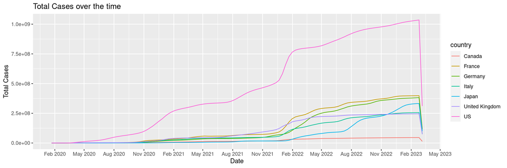

```r
df_viz <- g7_df_confirmed_aggregate_pivot %>%
  group_by(country, date_interval = cut.Date(date, breaks = "10 day")) %>%
  summarise(total_cases = sum(cases, na.rm = TRUE))
df_viz$date_interval <- as.Date(as.character(df_viz$date_interval))

ggplot(df_viz, aes(x = date_interval, y = total_cases, color = country)) +
  geom_line() +
  labs(title = "Total Cases over the time",
       x = "Date",
       y = "Total Cases") +
  scale_x_date(date_breaks = "3 month", date_labels = "%b %Y")
```

Infectious diseases spread by exponential rate. So, let’s try to visualize with log scale.

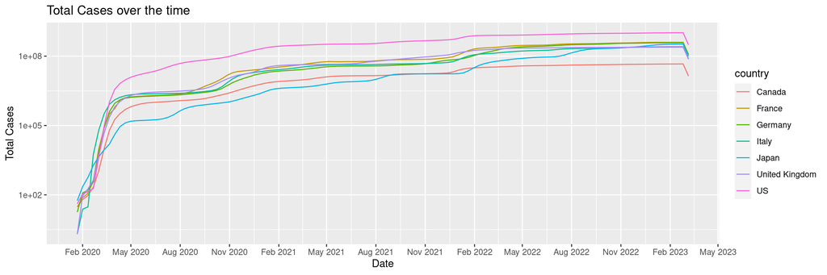

```r
df_viz <- g7_df_confirmed_aggregate_pivot %>%
  group_by(country, date_interval = cut.Date(date, breaks = "10 day")) %>%
  summarise(total_cases = sum(cases, na.rm = TRUE))
df_viz$date_interval <- as.Date(as.character(df_viz$date_interval))

ggplot(df_viz, aes(x = date_interval, y = total_cases, color = country)) +
  geom_line() +
  labs(title = "Total Cases over the time",
       x = "Date",
       y = "Total Cases") +
  scale_x_date(date_breaks = "3 month", date_labels = "%b %Y") +
  scale_y_log10()
```

### Out of the G7, Japan had a significant rise in confirmed cases starting from Feb 2022.

## Moving Average Plot for Japan

I want to do moving averages to see if there is something interesting in the data.

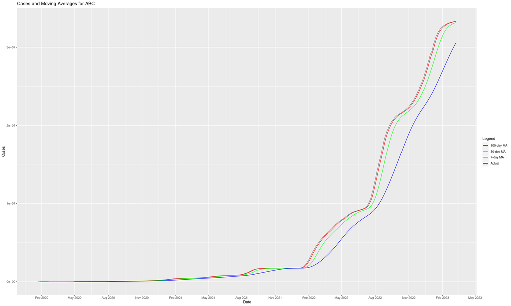

```r
df_japan <- g7_df_confirmed_aggregate_pivot %>%
  filter(country == "Japan")

# Sort and calculate moving averages
df_moving_avg <- df_japan %>%
  arrange(date) %>%
  mutate(
    moving_avg_7day = rollmean(cases, 7, align = "right", fill = NA),
    moving_avg_30day = rollmean(cases, 30, align = "right", fill = NA),
    moving_avg_100day = rollmean(cases, 100, align = "right", fill = NA)
  )

# Create the plot
ggplot(df_moving_avg, aes(x = date, y = cases)) +
  geom_line(aes(color = "Actual"), alpha = 0.5) +
  geom_line(aes(y = moving_avg_7day, color = "7-day MA")) +
  geom_line(aes(y = moving_avg_30day, color = "30-day MA")) +
  geom_line(aes(y = moving_avg_100day, color = "100-day MA")) +
  scale_color_manual(values = c("Actual" = "black", "7-day MA" = "red", "30-day MA" = "green", "100-day MA" = "blue")) +
  labs(title = "Cases and Moving Averages for ABC",
       x = "Date",
       y = "Cases",
       color = "Legend") +
  scale_x_date(date_breaks = "3 month", date_labels = "%b %Y")
```

## Important Deaths global dataset

```r
df_death = read_csv("./time_series_covid19_deaths_global.csv")
#head(df_death)
```

Again, we will looking only at the G7 countries.

```r
selected_countries <- c("Canada", "France", "Germany", "Italy", "Japan", "United Kingdom", "US")

# Filtering the data by selected countries
g7_df_death <- df_death %>% filter(`Country/Region` %in% selected_countries)

g7_df_death <- g7_df_death %>% rename(country = `Country/Region`)
#head(g7_df_death)
#View(g7_df_death)
```

```r
g7_df_death[c("Province/State", "Lat", "Long")] = list(NULL)
g7_df_death_aggregate <- aggregate(. ~ country, g7_df_death, sum)
#head(g7_df_death_aggregate)
```

```r
g7_df_death_aggregate_pivot <- g7_df_death_aggregate %>%
  pivot_longer(
    cols = -country,
    names_to = "date",
    values_to = "deaths"
  )

# Covert the day column to date object
g7_df_death_aggregate_pivot$date <- as.Date(g7_df_death_aggregate_pivot$date, format="%m/%d/%y")
#head(g7_df_death_aggregate_pivot)
```

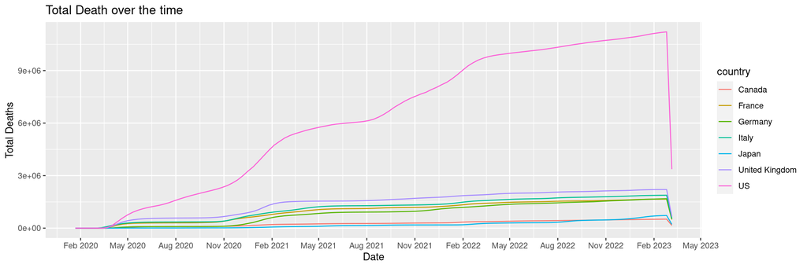

```r
df_viz <- g7_df_death_aggregate_pivot %>%
  group_by(country, date_interval = cut.Date(date, breaks = "10 day")) %>%
  summarise(total_deaths = sum(deaths, na.rm = TRUE))
df_viz$date_interval <- as.Date(as.character(df_viz$date_interval))

ggplot(df_viz, aes(x = date_interval, y = total_deaths, color = country)) +
  geom_line() +
  labs(title = "Total Death over the time",
       x = "Date",
       y = "Total Deaths") +
  scale_x_date(date_breaks = "3 month", date_labels = "%b %Y")
```

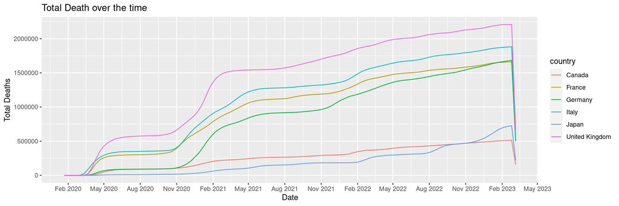

```r
df_without_us <- g7_df_death_aggregate_pivot %>%
  filter(country != "US")

df_viz <- df_without_us %>%
  group_by(country, date_interval = cut.Date(date, breaks = "10 day")) %>%
  summarise(total_deaths = sum(deaths, na.rm = TRUE))
df_viz$date_interval <- as.Date(as.character(df_viz$date_interval))

ggplot(df_viz, aes(x = date_interval, y = total_deaths, color = country)) +
  geom_line() +
  labs(title = "Total Death over the time",
       x = "Date",
       y = "Total Deaths") +
  scale_x_date(date_breaks = "3 month", date_labels = "%b %Y")
```

#### Visualization Without US

We can see the the trends are similar around Nov 2020 for all other countries except Japan. We see a exponentially significant rise in cases.

### Correlation between confirmed and deaths for US

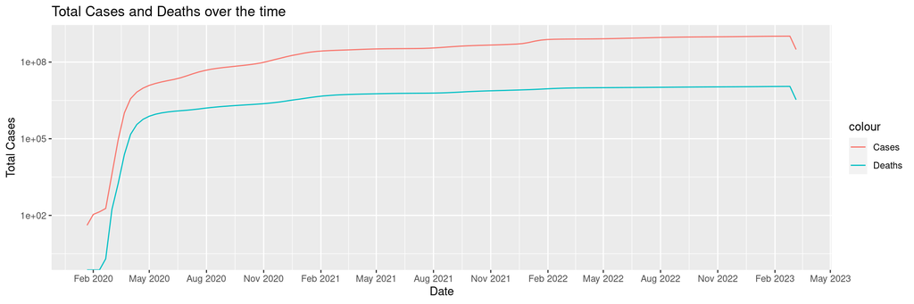

```r
df_us_confirmed <- g7_df_confirmed_aggregate_pivot %>%
  filter(country == "US")

df_viz <- df_us_confirmed %>%
  group_by(country, date_interval = cut.Date(date, breaks = "10 day")) %>%
  summarise(total_cases = sum(cases, na.rm = TRUE))
df_viz$date_interval <- as.Date(as.character(df_viz$date_interval))

plot <- ggplot(df_viz, aes(x = date_interval, y = total_cases, color = "Cases")) +
  geom_line() +
  labs(title = "Total Cases and Deaths over the time",
       x = "Date",
       y = "Total Cases") +
  scale_x_date(date_breaks = "3 month", date_labels = "%b %Y") +
  scale_y_log10()

df_us_death <- g7_df_death_aggregate_pivot %>%
  filter(country == "US")

df_viz2 <- df_us_death %>%
  group_by(country, date_interval = cut.Date(date, breaks = "10 day")) %>%
  summarise(total_deaths = sum(deaths, na.rm = TRUE))
df_viz2$date_interval <- as.Date(as.character(df_viz2$date_interval))

plot +
  geom_line(data = df_viz2, aes(x = date_interval, y = total_deaths, color = "Deaths"))
```

### Correlation between confirmed and deaths for Japan

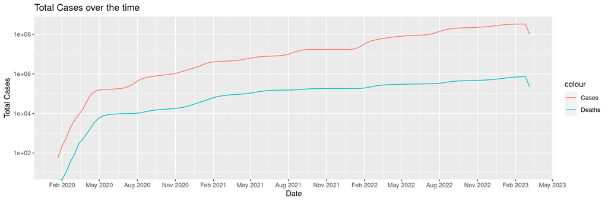

```r
df_japan_confirmed <- g7_df_confirmed_aggregate_pivot %>%
  filter(country == "Japan")

df_viz <- df_japan_confirmed %>%
  group_by(country, date_interval = cut.Date(date, breaks = "10 day")) %>%
  summarise(total_cases = sum(cases, na.rm = TRUE))
df_viz$date_interval <- as.Date(as.character(df_viz$date_interval))

plot <- ggplot(df_viz, aes(x = date_interval, y = total_cases, color = "Cases")) +
  geom_line() +
  labs(title = "Total Cases over the time",
       x = "Date",
       y = "Total Cases") +
  scale_x_date(date_breaks = "3 month", date_labels = "%b %Y") +
  scale_y_log10()

df_japan_death <- g7_df_death_aggregate_pivot %>%
  filter(country == "Japan")

df_viz2 <- df_japan_death %>%
  group_by(country, date_interval = cut.Date(date, breaks = "10 day")) %>%
  summarise(total_deaths = sum(deaths, na.rm = TRUE))
df_viz2$date_interval <- as.Date(as.character(df_viz2$date_interval))

plot +
  geom_line(data = df_viz2, aes(x = date_interval, y = total_deaths, color = "Deaths"))
```

This is no surprising to see cases and fatality are highly correlated.

## Data Modelling

I will perform a simple ARIMA model. I will use the first 300 days.

```r
df_japan_confirmed <- g7_df_confirmed_aggregate_pivot %>%
  filter(country == "Japan")

first_300_days <- df_japan_confirmed[1:300, ]
View(first_300_days)
```

```r
library(tseries)
adf_test <- adf.test(first_300_days$cases)
print(adf_test)
```

```
##
##  Augmented Dickey-Fuller Test
##
## data:  first_300_days$cases
## Dickey-Fuller = -1.1991, Lag order = 6, p-value = 0.9053
## alternative hypothesis: stationary
```

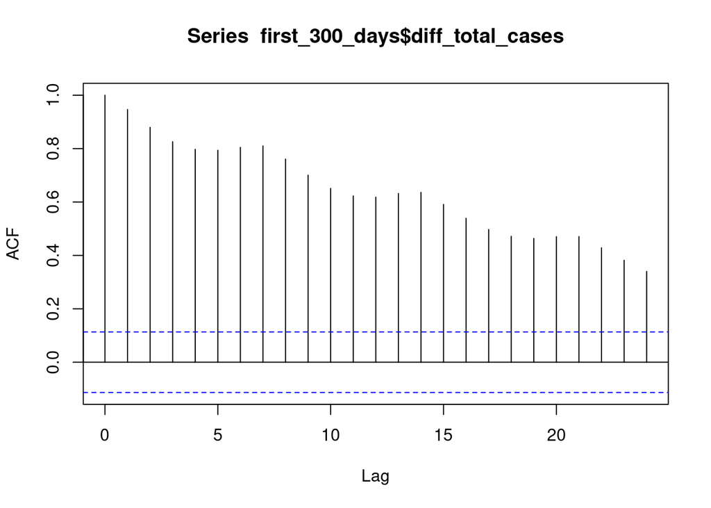

```r
first_300_days$diff_total_cases <- c(NA, diff(first_300_days$cases))
acf(first_300_days$diff_total_cases, na.action = na.omit)
```

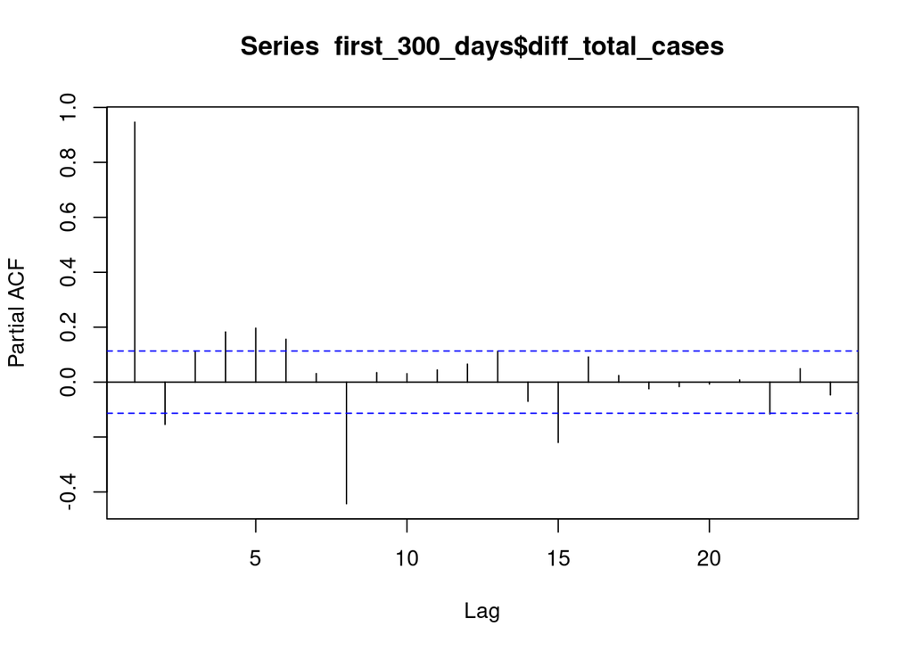

```r
pacf(first_300_days$diff_total_cases, na.action = na.omit)
```

```r
library(forecast)
fit <- auto.arima(first_300_days$cases)
summary(fit)
```

```
## Series: first_300_days$cases
## ARIMA(2,2,2)
##
## Coefficients:
##          ar1      ar2      ma1     ma2
##       1.2327  -0.9368  -1.3210  0.8005
## s.e.  0.0269   0.0381   0.0565  0.0426
##
## sigma^2 = 11891:  log likelihood = -1820
## AIC=3649.99   AICc=3650.2   BIC=3668.48
##
## Training set error measures:
##                    ME     RMSE      MAE      MPE     MAPE     MASE       ACF1
## Training set 6.378248 107.9482 68.67068 0.335241 1.703836 0.171852 -0.1159761
```

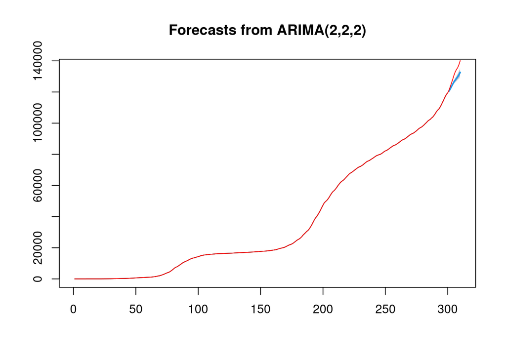

```r
future_values <- forecast(fit, h = 10)
plot(future_values)
lines(df_japan_confirmed[1:310, ]$cases, col = "red")
```

## Bias

I think we all are familiar with more or less. The main bias in this data is reporting accuracy. I don’t think reporting on new cases may not be timely manner as there may be delays in reporting and testing the cases.

To mention the facts that, in early days, testing could not be done effectively. I believe the actual data would have always lagged behind.

In the future, I would integrate more data sources to paint a better picture and to tell a better story. Time series data allow cannot tell the good story.